# Detection of Chagas Disease from the ECG: PhysioNet Challenge 2025

## Introduction

Chagas disease is a parasitic infection caused by Trypanosoma cruzi, primarily transmitted by triatomine insects. It can also spread through blood transfusions, organ transplants, and congenital transmission. The disease progresses in two phases: an acute phase, which often presents with mild or nonspecific symptoms such as fever, swollen lymph nodes, and localized swelling at the bite site, and a chronic phase, which develops over time. While most individuals in the chronic stage remain asymptomatic, 30-40% experience severe complications, particularly affecting the heart. Early treatment with antiparasitic drugs is effective, but its success diminishes as the infection advances.

Named after the Brazilian physician Carlos Chagas, who discovered it in 1909, the disease predominantly manifests in its chronic form, usually appearing 10 to 30 years after the initial infection. While the acute phase is generally mild or asymptomatic, the chronic stage can lead to serious cardiac and digestive complications. Diagnosis is typically made by detecting the parasite in the blood or identifying antibodies through serological tests.

Electrocardiography (ECG) plays a crucial role in identifying Chagas-related heart abnormalities. In the chronic stage, Chagas cardiomyopathy can result in progressive heart damage, conduction disorders such as atrioventricular blocks, ventricular arrhythmias, and dilated cardiomyopathy. In severe cases, it can lead to sudden cardiac death due to fatal arrhythmias like ventricular fibrillation. However, the indeterminate chronic form does not show ECG abnormalities, making early detection difficult.

## About the challenge

The **George B. Moody PhysioNet Challenge 2025** [[1]](https://moody-challenge.physionet.org/2025/) is a prestigious annual competition dedicated to advancing physiological and clinical problem-solving. This year's challenge focuses on Chagas disease, a parasitic infection widespread in Central and South America that poses a significant threat to cardiovascular health. Participants are tasked with developing open-source algorithms capable of detecting potential cases of Chagas disease using standard 12-lead electrocardiograms (ECGs). The goal is to enhance screening efforts by leveraging ECG data to identify individuals who may require confirmatory serological testing, thereby optimizing limited resources and improving patient outcomes.

Inspired by this challenge, our objective is to develop a model that can accurately detect Chagas disease using only a short (~10-second) 12-lead ECG recording as input

## Provided Data

The 2025 PhysioNet Challenge utilizes the **CODE-15% Database**[[2]](https://zenodo.org/records/4916206), a publicly accessible dataset comprising over 300,000 12-lead ECG recordings collected in Brazil between 2010 and 2016. The dataset includes binary Chagas disease labels, which are based on self-reported diagnoses and may incorporate responses from a questionnaire.

Each ECG record is accompanied by a WFDB header file containing essential metadata, including sampling frequency, signal parameters, demographic information (when available), and Chagas labels. For example, record 113 from the CODE-15% Database consists of 12 channels, a sampling frequency of 400 Hz, and 4096 samples per channel.

The ECG data are stored in WFDB files, requiring specific processing methods. To handle this format efficiently, we utilized the helper functions provided by the challenge organizers in their official documentation.

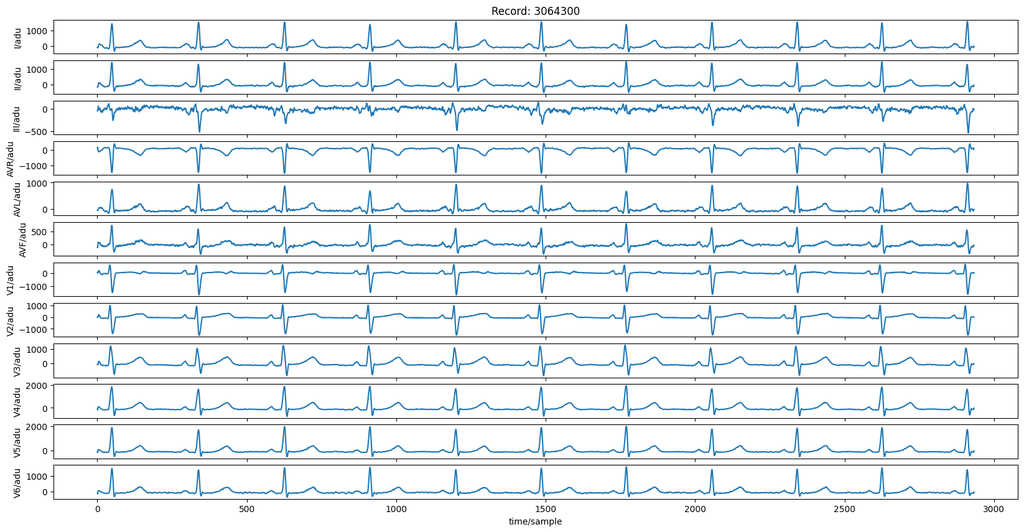

```python
wfdb.plot_wfdb(record=wfdb.rdrecord(record, physical=False), figsize=(20, 10), time_units='samples')
```

## Creation of the dataset

[figure not shown]

To effectively analyze the ECG time series, it is necessary to extract relevant features that capture specific characteristics of the signal.

These features are defined by the occurrence of key fiducial points (P, Q, R, S, and T waves) as well as the duration of the segments between them. By measuring these temporal intervals, we can derive numerical representations of the ECG signal, which serve as inputs for classical machine learning (ML) algorithms to perform classification.

Existing literature has demonstrated that the duration of these ECG patterns is strongly associated with the presence or absence of Chagas disease, making them critical features for the detection and diagnosis of the condition.

The feature extraction process is implemented in the `preprocessing.py` file, which utilizes the [NeuroKit2](https://neuropsychology.github.io/NeuroKit/) library to extract relevant characteristics from the ECG dataset.

To ensure a comprehensive analysis, we initially extract all available features provided by the library. A subsequent feature selection process, performed later in the notebook, will identify the most informative features for classification, optimizing model performance and reducing potential redundancy in the dataset.

**Important**:

The original dataset provided for the challenge contains a **large volume of ECG recordings**, making it computationally expensive to process in its entirety. Working with the full dataset would have significantly slowed development and posed challenges when using online platforms such as Google Colab or Kaggle, which have resource limitations. To address this, **we opted to work with a partitioned subset of the data**, enabling more efficient experimentation and model development.

Additionally, the original dataset exhibited a notable class imbalance, with seropositive cases being significantly underrepresented compared to seronegative cases. By downsampling the dataset, we were able to balance the number of examples per class, ensuring a more effective and unbiased training process for our classification model.

# Exploratory Data Analysis

```python
df.chagas.value_counts(normalize=True)
```

```
chagas
True     0.500153
False    0.499847
Name: proportion, dtype: float64
```

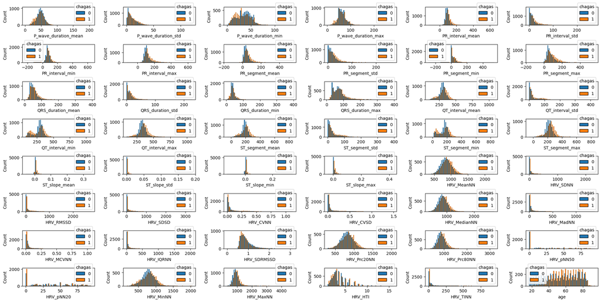

```python
_, axes = plt.subplots(nrows=8, ncols=6, figsize=(20, 10))
for ax, cname in zip(axes.ravel(), num_cols):
    sn.histplot(data=df, x=cname, bins=50, stat="count", alpha=1, kde=False, multiple='dodge', ax=ax, hue='chagas')
plt.tight_layout()
plt.show()
```

```python
t_test_df.sort_values(by='p_value')
```

|  | column | t_stat | p_value | is_significant |
| --- | --- | --- | --- | --- |
| 6 | PR_segment_mean | 20.819895 | 1.633643e-94 | True |
| 7 | PR_segment_max | 20.634896 | 4.930207e-93 | True |
| 5 | PR_interval_max | 18.113069 | 2.226532e-72 | True |
| 21 | HRV_MaxNN | 15.886669 | 2.847833e-56 | True |
| 3 | PR_interval_mean | 15.732206 | 3.498921e-55 | True |
| 0 | P_wave_duration_mean | -15.235253 | 5.901368e-52 | True |
| 15 | ST_segment_max | 14.821371 | 2.896867e-49 | True |
| 17 | HRV_SDRMSSD | -14.733790 | 9.797298e-49 | True |
| 19 | HRV_Prc80NN | 13.986132 | 4.023160e-44 | True |
| 1 | P_wave_duration_min | -13.572657 | 1.116486e-41 | True |
| 13 | QT_interval_max | 12.460313 | 2.006407e-35 | True |
| 22 | HRV_HTI | -11.860685 | 2.772502e-32 | True |
| 16 | HRV_MedianNN | 10.322695 | 6.949631e-25 | True |
| 10 | QRS_duration_max | 9.578422 | 1.166052e-21 | True |
| 8 | QRS_duration_mean | 9.532662 | 1.821155e-21 | True |
| 2 | P_wave_duration_max | -8.089928 | 6.502718e-16 | True |
| 18 | HRV_Prc20NN | 6.024534 | 1.742408e-09 | True |
| 4 | PR_interval_min | 5.904194 | 3.640283e-09 | True |
| 14 | ST_segment_mean | 5.721862 | 1.079176e-08 | True |
| 12 | QT_interval_min | -4.514126 | 6.416034e-06 | True |
| 11 | QT_interval_mean | 3.694889 | 2.209494e-04 | True |
| 9 | QRS_duration_min | 3.558609 | 3.743054e-04 | True |
| 20 | HRV_MinNN | 2.215779 | 2.672431e-02 | True |

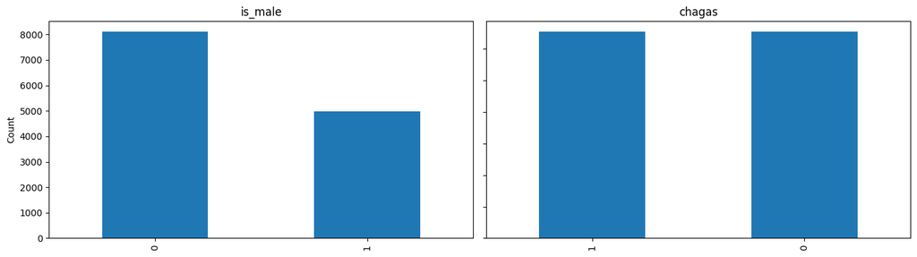

```python
_, axes = plt.subplots(nrows=1, ncols=2)
for i, cname in enumerate(cat_cols + ['chagas']):
    df[cname].value_counts().plot(kind='bar', ax=axes[i], figsize=figsize, title=cname, ylabel='Count', xlabel='', sharey=True)

plt.tight_layout()
```

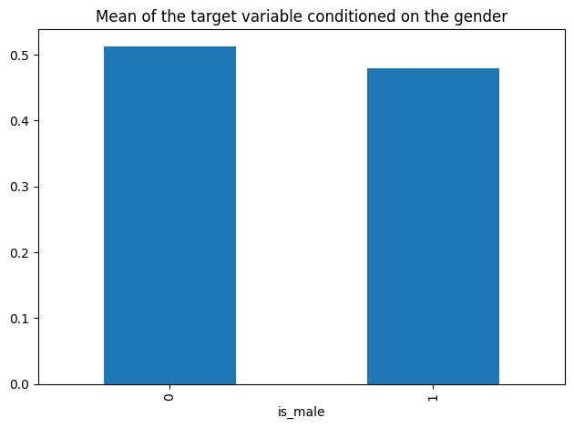

```python
df.groupby('is_male')['chagas'].mean().plot.bar(title='Mean of the target variable conditioned on the gender')
plt.tight_layout()
```

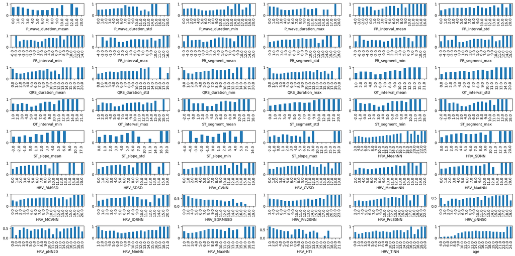

```python
_, axes = plt.subplots(nrows=8, ncols=6, figsize=(20,10))
for ax, cname in zip(axes.ravel(), num_cols):
    bin_size = (df[cname].max() - df[cname].min()) / 20
    df['chagas'].groupby(df[cname] // bin_size).mean().plot.bar(ax=ax)
plt.tight_layout()
```

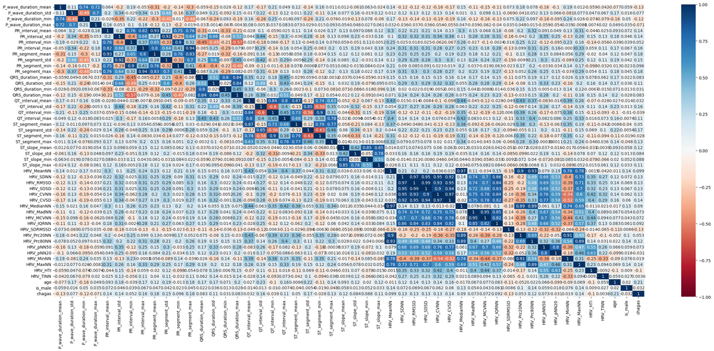

```python
plt.figure(figsize=(27,12))
sn.heatmap(df.corr(method='pearson'), annot=True, vmin=-1, vmax=1, cmap='RdBu')
plt.tight_layout()
```

## A more in-depth analysis of the data

In order to perform a more in-depth analysis we researched what are the most common indicator of the chagas disease present in the ecg and which are the most common symptoms. Our main finding are that:

### Ventricular Rate

The ventricular rate refers to the number of times the ventricles contract per minute, typically measured as the heart rate (beats per minute, BPM) on an ECG, and it reflects the overall pacing of the heart's electrical activity. To evaluate the claim presented earlier about this features are also true in our dataset we constructed a boxplot illustrating the distribution of ventricular rate across four distinct age groups.

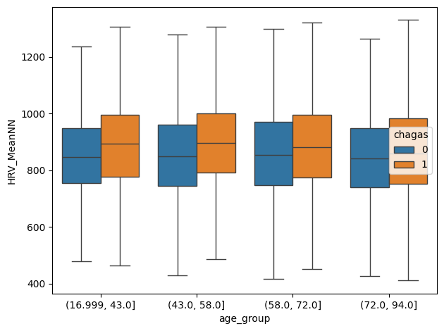

```python
df['age_group'] = pd.qcut(df['age'], q=4)
sn.boxplot(x='age_group', y='HRV_MeanNN', hue='chagas', data=df, showfliers=False)
plt.tight_layout()
plt.show()
```

### Heart rate variability (HRV)

`HRV_HTI` is the triangular index, measuring the total number of RR intervals divided by the height of the RR intervals. If the number of total RR intervals is the same, then the HRV_HTI is higher if the RR intervals are more regular (since the majority of the RR intervals are close to the mean).

Visualizing the distribution of HRV_HTI via boxplots segmented by age allows us to examine potential variations in heart rate regularity across different age groups. Such analysis is particularly valuable in the context of Chagas disease, which is known to affect the autonomic regulation of the heart and may lead to increased irregularity in the RR intervals. By comparing the HRV_HTI across age groups, we can identify trends that may correlate with the disease’s progression, thereby providing insights into its impact on cardiac function and aiding in the identification of Chagas disease.

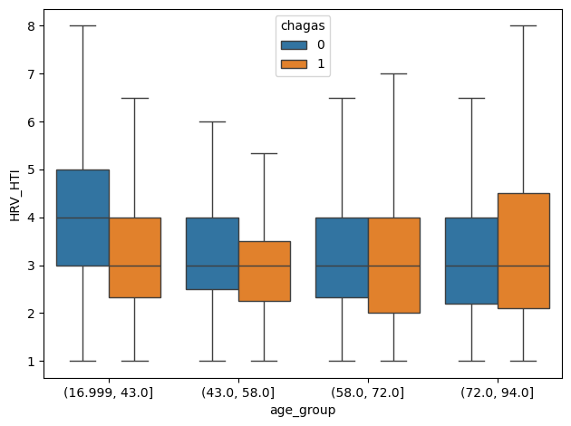

```python
df['age_group'] = pd.qcut(df['age'], q=4)
sn.boxplot(x='age_group', y='HRV_HTI', hue='chagas', data=df, showfliers=False)
plt.tight_layout()
plt.show()
```

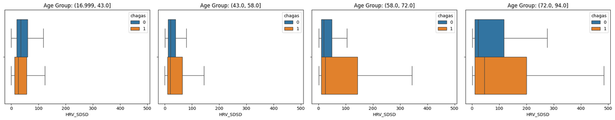

```python
age_groups = df['age_group'].cat.categories if pd.api.types.is_categorical_dtype(df['age_group']) else sorted(df['age_group'].unique())
n_groups = len(age_groups)
fig, axes = plt.subplots(1, n_groups, figsize=(5 * n_groups, 4), sharex=True, sharey=True)

for ax, group in zip(axes, age_groups):
    subset = df[df['age_group'] == group]
    sn.boxplot(data=subset, x='HRV_SDSD', hue='chagas', ax=ax, showfliers=False)
    ax.set_title(f'Age Group: {group}')

plt.tight_layout()
plt.show()
```

### QRS Duration

To investigate the potential role of QRS duration in identifying seropositive patients, we generated a boxplot of the mean QRS duration (QRS_duration_mean) for each age group, using the target variable as the distinguishing hue.

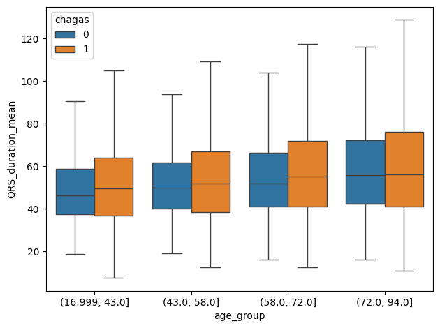

```python
df['age_group'] = pd.qcut(df['age'], q=4)
sn.boxplot(x='age_group', y='QRS_duration_mean', hue='chagas', data=df, showfliers=False)
plt.tight_layout()
plt.show()
```

### PR duration

To investigate the electrophysiological alterations associated with Chagas disease, we constructed boxplots for both the mean PR segment (PR_segment_mean) and the mean PR interval (PR_interval_mean) across different age groups, with the target variable used as the hue to differentiate between seropositive and seronegative patients.

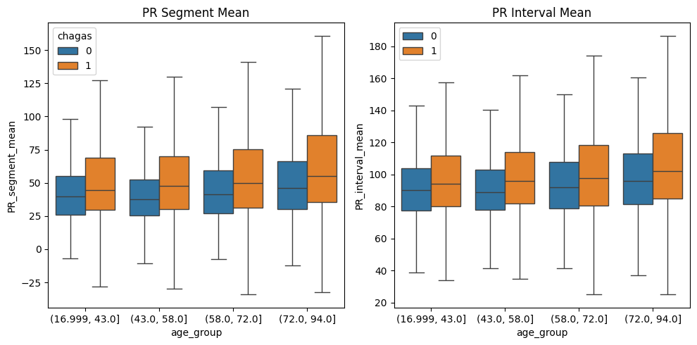

```python
df['age_group'] = pd.qcut(df['age'], q=4)
plt.figure(figsize=(10, 5))
plt.subplot(1, 2, 1)
sn.boxplot(x='age_group', y='PR_segment_mean', hue='chagas', data=df, showfliers=False)
plt.title('PR Segment Mean')
plt.subplot(1, 2, 2)
sn.boxplot(x='age_group', y='PR_interval_mean', hue='chagas', data=df, showfliers=False)
plt.title('PR Interval Mean')
plt.legend()
#plt.grid(axis='y')
plt.tight_layout()
plt.show()
```

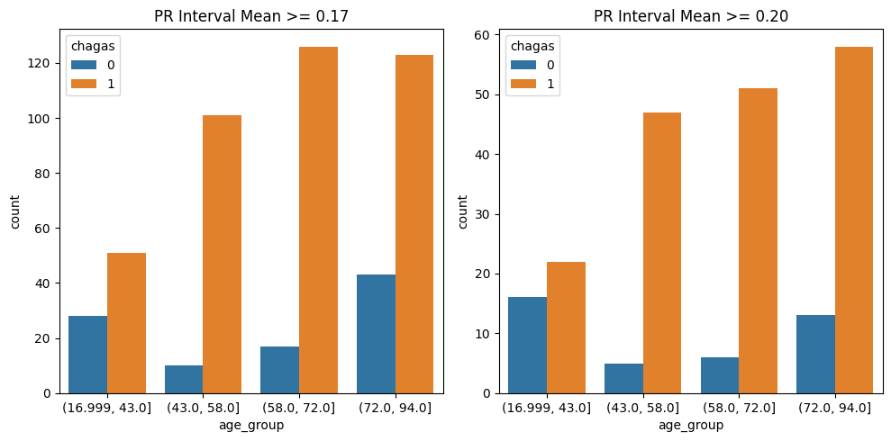

```python
plt.figure(figsize=(10, 5))
plt.subplot(1, 2, 1)
sn.barplot(df[df['PR_interval_mean'] / 1000 >= 0.17].groupby('age_group')['chagas'].value_counts().reset_index(), x='age_group', y='count', hue='chagas')
plt.title('PR Interval Mean >= 0.17')
plt.subplot(1, 2, 2)
sn.barplot(df[df['PR_interval_mean'] / 1000 >= 0.20].groupby('age_group')['chagas'].value_counts().reset_index(), x='age_group', y='count', hue='chagas')
plt.title('PR Interval Mean >= 0.20')
plt.tight_layout()
plt.show()
```

### Standardization of the data

The StandardScaler is applied to the numerical columns to have a better distribution of the data by subtracting the mean and dividing by the standard deviation.

We first dropped the `age_group` column since it was not used inside our models and then applied the StandardScaler to the numerical columns.

For the `age` column, we applied Min-Max scaling to have a better distribution of the data in the range of 0 and 1.

The splitting between training and testing sets is done by stratifying the target variable and shuffling the data. For the test set, we used 20% of the data.

```python
X, y = df.drop(columns=['chagas', 'age_group'], axis=1), df['chagas']

X['age'] = ((X['age'] - X['age'].min()) / (X['age'].max() - X['age'].min())).astype(float)

X_train, X_test, y_train, y_test = train_test_split(X, y, test_size=0.2, random_state=SEED, stratify=y, shuffle=True)
scaler = StandardScaler()
X_train.iloc[:, :-2] = scaler.fit_transform(X_train.iloc[:, :-2])
X_test.iloc[:, :-2] = scaler.transform(X_test.iloc[:, :-2])
```

```python
results_dict = {}

def print_results(model, y_test, y_pred, y_pred_proba):
    acc = accuracy_score(y_test, y_pred)
    auc = roc_auc_score(y_test, y_pred_proba)
    f1 = f1_score(y_test, y_pred)
    f_beta = fbeta_score(y_test, y_pred, beta=0.5)
    print(f'Accuracy: {acc:.4f}')
    print(f'ROC-AUC: {auc:.4f}')
    print(f'F1-score: {f1:.4f}')
    print("F-beta score", f_beta)
    sn.heatmap(confusion_matrix(y_test, y_pred, labels=[0, 1], normalize="all"), annot=True, cmap='viridis')
    plt.tight_layout()
    plt.show()
    return {'acc': acc, 'auc': auc, 'f1': f1, 'f_beta': f_beta}
```

# Logistic Regression

We start with a Logistic Regression model that uses L1 regularization to promote sparsity in the coefficients, which helps in identifying and eliminating less useful features. The saga solver was chosen because it efficiently handles L1 regularization and scales well with large datasets.

The hyperparameter `C`, which inversely controls the regularization strength, was tuned using `GridSearchCV` with the ROC-AUC metric as our performance measure.

Additionally, we observed that the model did not fully converge within the allotted maximum iterations (`max_iter=100`). This may imply that either the decision boundary is complex for a linear classifier or that more iterations (or further tuning) are necessary to achieve convergence.

$$\text{argmin}_{\theta}\ H\biggl(y, f(x,\theta)\biggr) + \frac{1}{C} ||\theta||_1$$

Although it might appear that the grid search for the regularization parameter C in Logistic Regression would simply favor a very high value (i.e., minimal regularization) to maximize the ROC-AUC by allowing the model to fit the training data as closely as possible, the process of tuning C is crucial for several reasons.

First, the optimal C is determined by a balance between bias and variance—strong regularization (small C) could underfit the data, while weak regularization (large C) might overfit, especially in noisy or complex datasets. The grid search with cross-validation systematically evaluates a range of C values to identify the model that generalizes best to unseen data, rather than merely optimizing performance on the training set.

Additionally, even if the grid search eventually selects a high C for our data, this outcome is an important, data-driven insight: it indicates that, under the current conditions, the model does not benefit significantly from strong regularization. Moreover, tuning C helps ensure that we are not inadvertently neglecting the potential benefits of L1 regularization, such as sparsity and feature selection, which can enhance interpretability and robustness when the data conditions change.

```python
lr_score_cv, lr_score_test = gscv.best_score_, roc_auc_score(y_test, lr.predict_proba(X_test)[:, 1])
print(f'AUC score for C={lr_params["C"]:.2f}: {lr_score_cv:.2f} (cross-validation), {lr_score_test:.2f} (test)')
```

```
AUC score for C=10.00: 0.75 (cross-validation), 0.75 (test)
```

```
Accuracy: 0.6817
ROC-AUC: 0.7457
F1-score: 0.6711
F-beta score 0.684931506849315
```

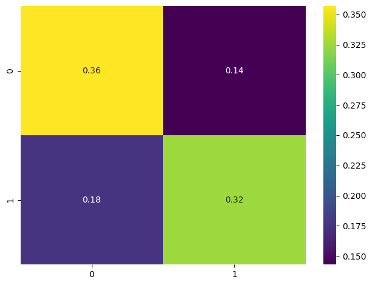

```python
results_dict['Logistic Regression'] = print_results(lr, y_test, lr.predict(X_test), lr.predict_proba(X_test)[:, 1])
```

```python
pd.DataFrame({'variable': X.columns, 'coeff': np.abs(lr.coef_[0]), 'sign': ['neg' if lr.coef_[0][i] < 0 else 'pos' for i in range(len(X.columns))]}).sort_values(by='coeff', ascending=False).head(20)
```

|  | variable | coeff | sign |
| --- | --- | --- | --- |
| 47 | age | 0.853942 | pos |
| 21 | ST_segment_std | 0.752433 | pos |
| 32 | HRV_CVNN | 0.751664 | pos |
| 44 | HRV_MaxNN | 0.631701 | neg |
| 1 | P_wave_duration_std | 0.616661 | pos |
| 22 | ST_segment_min | 0.551206 | pos |
| 3 | P_wave_duration_max | 0.531277 | neg |
| 2 | P_wave_duration_min | 0.487208 | pos |
| 39 | HRV_Prc20NN | 0.472132 | pos |
| 12 | QRS_duration_mean | 0.455444 | pos |
| 20 | ST_segment_mean | 0.390007 | pos |
| 33 | HRV_CVSD | 0.380567 | pos |
| 29 | HRV_SDNN | 0.356512 | pos |
| 16 | QT_interval_mean | 0.347580 | neg |
| 42 | HRV_pNN20 | 0.345703 | neg |
| 48 | is_male | 0.336190 | neg |
| 11 | PR_segment_max | 0.312340 | neg |
| 24 | ST_slope_mean | 0.309829 | pos |
| 31 | HRV_SDSD | 0.280615 | neg |
| 43 | HRV_MinNN | 0.269078 | pos |

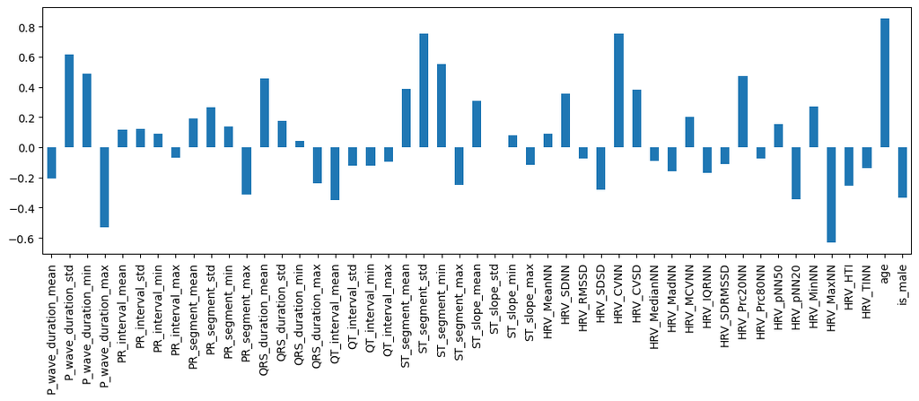

```python
lr_coefs = pd.Series(index=X.columns, data=lr.coef_[0])
lr_coefs.plot(kind='bar', figsize=figsize)
plt.show()
```

# XGBoost

The second model that we tried is the XGBoost. We used the `hist` tree method because of its computational efficiency (especially with large datasets) and the `total_gain` importance type. In particular, the total gain importance is helpful for explainable AI since it takes into account the improvements in performances that a feature contributes across all the splits where it is utilized in the decision trees (thus considering both the frequency and the magnitude of importance of a feature for the final results).

```python
base_est = xgboost.XGBClassifier(tree_method='hist', importance_type='total_gain', n_jobs=-1)
param_grid={'max_depth': [2, 3, 4], 'n_estimators': list(range(20, 41, 5)), 'reg_lambda': np.linspace(0, 500, 6)}
gscv = GridSearchCV(base_est, param_grid=param_grid, n_jobs=-1)
gscv.fit(X_train, y_train)
xbm, xbm_params = gscv.best_estimator_, gscv.best_params_
```

```python
xbm_score_test = roc_auc_score(y_test, xbm.predict_proba(X_test)[:, 1])
print(f'AUC score for max_depth={xbm_params["max_depth"]}, n_estimators={xbm_params["n_estimators"]}, reg_lambda={xbm_params["reg_lambda"]:.2f}: {xbm_score_test:.2f} (test)')
```

```
AUC score for max_depth=4, n_estimators=40, reg_lambda=100.00: 0.78 (test)
```

```
Accuracy: 0.7050
ROC-AUC: 0.7813
F1-score: 0.7145
F-beta score 0.7011177239076789
```

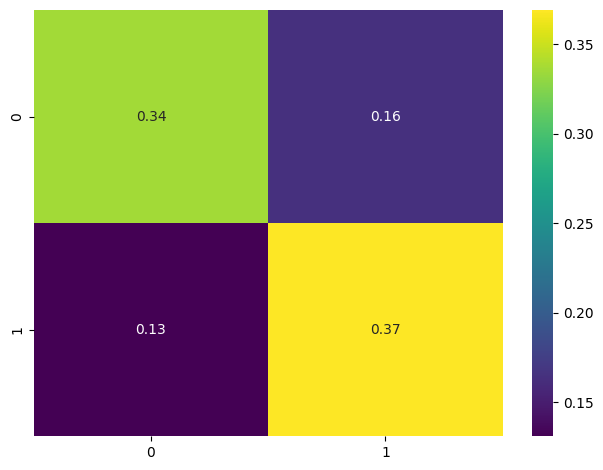

```python
results_dict['XGBoost'] = print_results(xbm, y_test, y_pred=xbm.predict(X_test), y_pred_proba=xbm.predict_proba(X_test)[:, 1])
```

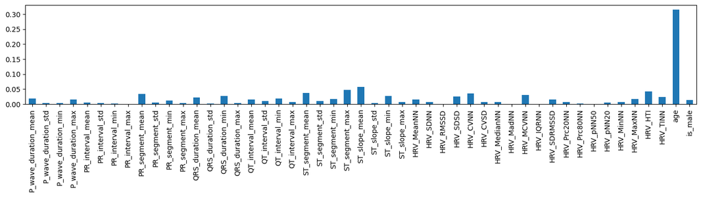

```python
xbm_imp = pd.Series(index=X.columns, data=xbm.feature_importances_)
xbm_imp.plot(kind='bar', figsize=figsize)
plt.tight_layout()
plt.show()
```

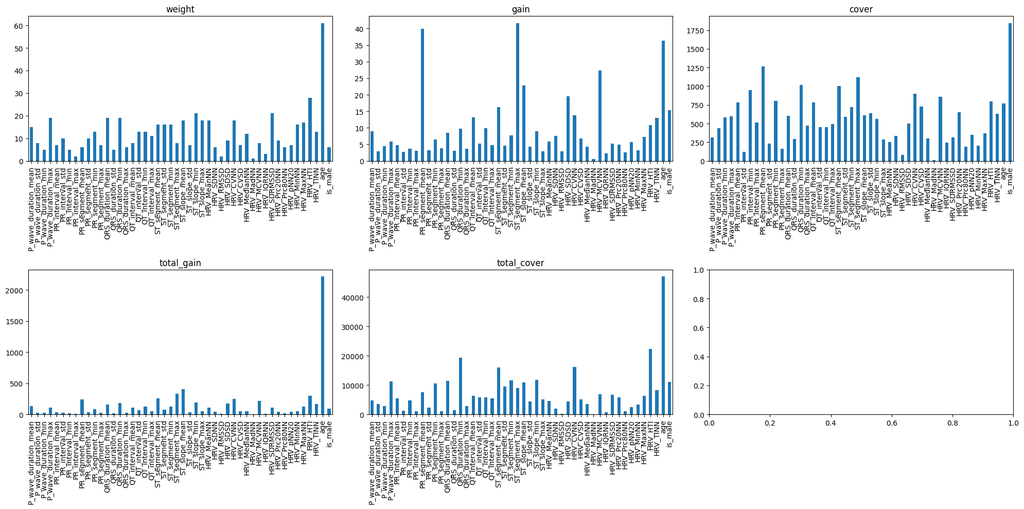

```python
_, axes = plt.subplots(nrows=2, ncols=3, figsize=(20, 10))
for ax, imp_type in zip(axes.ravel(), ['weight', 'gain', 'cover', 'total_gain', 'total_cover']):
    pd.Series(xbm.get_booster().get_score(importance_type=imp_type)).plot.bar(ax=ax, title=imp_type)
plt.tight_layout()
```